# Reproducible Research: Peer Assessment 1

I Carter (Coursera)

## Loading and preprocessing the data

### Load the data

```r
data <- read.csv("activity.csv")
```

### Process/transform the data into a format suitable for your analysis

`data$interval` is like `rep(0:11 * 5, 24) + rep(0:23 * 100, each=12)`  
viz. like 0, 5, …, 50, 55, 100, 105, …  
we want it like 0, 5, …, 50, 55, 60, 65, …

This is so that we can make time series plots (otherwise the jump from 55 to 100 makes a difficulty).

We also want it to be a factor variable, but we want to keep the original `interval` column, so we call our new factor `interval_new`. There is no real need to turn our old `interval` column into a factor, but we will anyway.

```r
data$interval <- as.factor(data$interval)
data$interval_new <- as.factor(rep(0:287 * 5, 61))
```

### Taking a look at the dataset

```r
## Take a look at the data:
dim(data)
```

```
## [1] 17568     4
```

```r
str(data)
```

```
## 'data.frame':    17568 obs. of  4 variables:
##  $ steps       : int  NA NA NA NA NA NA NA NA NA NA ...
##  $ date        : Factor w/ 61 levels "2012-10-01","2012-10-02",..: 1 1 1 1 1 1 1 1 1 1 ...
##  $ interval    : Factor w/ 288 levels "0","5","10","15",..: 1 2 3 4 5 6 7 8 9 10 ...
##  $ interval_new: Factor w/ 288 levels "0","5","10","15",..: 1 2 3 4 5 6 7 8 9 10 ...
```

## What is mean total number of steps taken per day?

Ignore any missing values.

### Histogram of the total number of steps taken each day

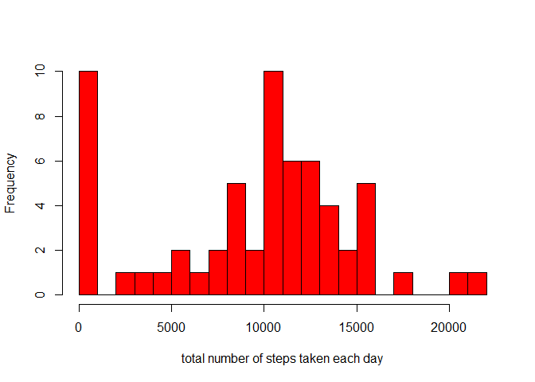

```r
library(lattice)
total <- tapply(data$steps, data$date, sum, na.rm=TRUE)
hist(total, breaks=22, col="red", main="",
    xlab="total number of steps taken each day")
```

A lot of zero values.

### The *mean* and *median* total number of steps taken per day

```r
mean_orig <- mean(total)
median_orig <- median(total)
print(paste("Mean is:", mean_orig, ";  Median is:", median_orig))
```

```
## [1] "Mean is: 9354.22950819672 ;  Median is: 10395"
```

## What is the average daily activity pattern?

### Time Series Plot

5-minute interval on the x-axis; average number of steps taken (averaged across all days) on the y-axis.

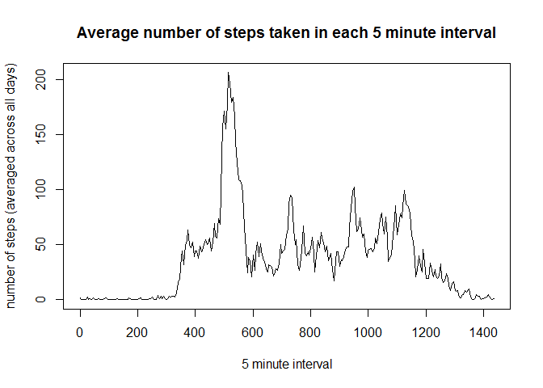

```r
intervals <- tapply(data$steps, data$interval_new, mean, na.rm=TRUE)
plot(intervals~levels(data$interval_new), type="l",
    main="Average number of steps taken in each 5 minute interval",
    xlab="5 minute interval",
    ylab="number of steps (averaged across all days)")
```

The time series plot would not come out right if we used the original `data$interval` column (because of the jumps from, e.g. 55 to 100, meaning from the 55 mark to the 1 hour mark). `data$interval_new` fixes this by putting the number of minutes on the x-axis, e.g. going from 55 to 60, so the highest value is 1435 (1440-5), instead of 2355 (24:00-5) as in the original data.

### The 5-minute interval which contains the most steps

The 5-minute interval which on average across all the days in the dataset contains the maximum number of steps:

```r
temp <- data$interval_new[which.max(intervals)]
temp <- as.numeric(levels(data$interval))[temp]
paste("the interval from", temp, "to", temp+5, "contains the greatest number of steps, averaged over all the days.")
```

```
## [1] "the interval from 835 to 840 contains the greatest number of steps, averaged over all the days."
```

This prints out using the original `data$interval` format, i.e. 835 to 840 means 08:35 to 08:40. I guess our guy walks to work.

## Imputing missing values

Note that there are a number of days/intervals where there are missing values (coded as `NA`). The presence of missing days may introduce bias into some calculations or summaries of the data.

### total number of missing values

The total number of rows in the dataset with NAs:

```r
sum(is.na(data))
```

```
## [1] 2304
```

The percentage of rows in the dataset with NAs:

```r
sum(is.na(data)) / length(data$steps) * 100
```

```
## [1] 13.11475
```

### strategy for filling in all of the missing values

Devise a strategy for filling in all of the missing values in the dataset. The strategy does not need to be sophisticated.

*Here we use the mean for each 5-minute interval.*

```r
## same as before
intervals <- tapply(data$steps, data$interval_new, mean, na.rm=TRUE)
intervals <- rep(intervals, 61)
```

### new dataset with missing values filled in

Create a new dataset that is equal to the original dataset but with the missing data filled in.

```r
data_new <- data        ## make new dataset
data_new$steps <- ifelse(is.na(data_new$steps), intervals, data_new$steps)
```

### histogram of the total number of steps taken each day

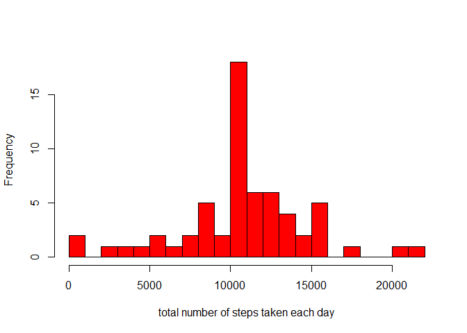

```r
## same code as above, but with filled-in dataset
total_new <- tapply(data_new$steps, data_new$date, sum)    ## na.rm=FALSE
hist(total_new, breaks=22, col="red", main="",
    xlab="total number of steps taken each day")
```

There is no longer the large number of zero values (which were probably caused by NAs).  
The center spike is also a good bit higher.

### the *mean* and *median* total number of steps taken per day

```r
mean_new <- mean(total_new)
median_new <- median(total_new)
print(paste("Mean is:", mean_new, ";  Median is:", median_new))
```

```
## [1] "Mean is: 10766.1886792453 ;  Median is: 10766.1886792453"
```

### Report on impact of imputing missing data

*Do these values differ from the estimates from the first part of the assignment?*  
Answer = Yes, the funny thing is that the mean and the median are now the same!  
I think this has something to do with filling in the data using the mean value for each interval.

*What is the impact of imputing missing data on the estimates of the total daily number of steps?*  
Answer = The mean and the median are a bit higher when calculated using imputed missing data, but the difference is not very great.

```r
print(paste("New mean:", mean_new, "(old:", mean_orig,
    ");"))
```

```
## [1] "New mean: 10766.1886792453 (old: 9354.22950819672 );"
```

```r
print(paste("New median:", median_new, "(old:", median_orig, ")."))
```

```
## [1] "New median: 10766.1886792453 (old: 10395 )."
```

## Are there differences in activity patterns between weekdays and weekends?

*Using the dataset with the filled-in missing values.*

### weekend vs. weekday

Create a new factor variable in the dataset with two levels – “weekday” and “weekend” indicating whether a given date is a weekday or weekend day.

```r
levels <- c("Monday", "Tuesday", "Wednesday", "Thursday",
    "Friday", "Saturday", "Sunday")
labels <- c("weekday", "weekday", "weekday", "weekday",
    "weekday", "weekend", "weekend")
data_new$weekdays <- weekdays(as.Date(data_new$date))
data_new$weekdays <- factor(data_new$weekdays, levels=levels, labels=labels)
```

### Time Series Plots

Make a panel plot containing a time series plot (i.e. `type = "l"`) of the 5-minute interval (x-axis) and the average number of steps taken, averaged across all weekday days or weekend days (y-axis).

### Average number of steps taken in each 5 minute interval (weekday vs. weekend)

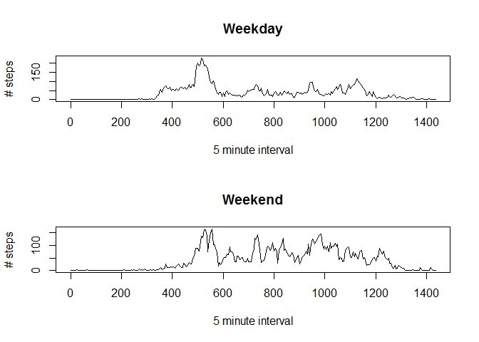

```r
temp_new <- tapply(data_new$steps,
    list(data_new$interval_new, data_new$weekdays), mean)
par(mfrow=c(2, 1))
plot(temp_new[,"weekday"]~levels(data_new$interval_new), type="l",
    main="Weekday",
    xlab="5 minute interval",
    ylab="# steps")
plot(temp_new[,"weekend"]~levels(data_new$interval_new), type="l",
    main="Weekend",
    xlab="5 minute interval",
    ylab="# steps")
```

There are definite differences in activity pattern between weekdays and weekend.

There is a high burst of activity on weekday mornings, which doesn’t occur as much on weekends. In general the bulk of activity at weekends starts a bit later and ends a bit later than on weekdays, and there is more activity overall at the weekend.

This document was processed on: 2020-06-17.